# Tarea-04

Author

Thomas M. Rudolf

Cargamos los paquetes que necesitaremos:

```r
library(tidyverse)
library(nullabor)
library(patchwork)
```

## Pruebas visuales y Permutación

#### Pruebas de permutación

1. La tabla de datos *Phillies2009* contiene información de la temporada de baseball 2009 para el equipo de Philadelphia *Phillies*, en este ejercicio queremos comparar los strikes (`StrikeOuts`) entre los juegos en casa y de visitante:

```r
# Lectura de datos
phillies <- read_csv("Phillies2009.csv")
glimpse(phillies)
```

```
Rows: 162
Columns: 7
$ Date       <chr> "5-Apr", "7-Apr", "8-Apr", "10-Apr", "11-Apr", "12-Apr", "1…
$ Location   <chr> "Home", "Home", "Home", "Away", "Away", "Away", "Away", "Aw…
$ Outcome    <chr> "Lose", "Lose", "Win", "Lose", "Win", "Win", "Win", "Lose",…
$ Hits       <dbl> 4, 6, 11, 7, 15, 13, 10, 5, 14, 8, 9, 13, 8, 2, 8, 9, 12, 1…
$ Doubles    <dbl> 2, 1, 3, 2, 3, 3, 3, 1, 3, 2, 1, 4, 0, 0, 2, 0, 2, 5, 0, 0,…
$ HomeRuns   <dbl> 0, 0, 1, 1, 1, 2, 3, 0, 1, 3, 3, 1, 1, 1, 2, 2, 0, 2, 4, 1,…
$ StrikeOuts <dbl> 6, 3, 6, 3, 6, 4, 7, 3, 5, 7, 5, 8, 4, 4, 12, 8, 7, 7, 5, 8…
```

1. Realiza un *lineup* donde cada panel muestre un diagrama de caja y brazos para la variable de interés separando los juegos jugados en casa (home) y los juegos jugados fuera (away). ¿Puedes localizar los datos verdaderos entre los nulos?

```r
# Line up data
set.seed(123)
perms_Location <- lineup(null_permute("Location"), phillies, n = 12)
```

```
decrypt("nsW7 Ykjk l3 gCPljlC3 4b")
```

```r
glimpse(perms_Location)
```

```
Rows: 1,944
Columns: 8
$ Date       <chr> "5-Apr", "7-Apr", "8-Apr", "10-Apr", "11-Apr", "12-Apr", "1…
$ Location   <chr> "Home", "Home", "Away", "Home", "Home", "Home", "Home", "Aw…
$ Outcome    <chr> "Lose", "Lose", "Win", "Lose", "Win", "Win", "Win", "Lose",…
$ Hits       <dbl> 4, 6, 11, 7, 15, 13, 10, 5, 14, 8, 9, 13, 8, 2, 8, 9, 12, 1…
$ Doubles    <dbl> 2, 1, 3, 2, 3, 3, 3, 1, 3, 2, 1, 4, 0, 0, 2, 0, 2, 5, 0, 0,…
$ HomeRuns   <dbl> 0, 0, 1, 1, 1, 2, 3, 0, 1, 3, 3, 1, 1, 1, 2, 2, 0, 2, 4, 1,…
$ StrikeOuts <dbl> 6, 3, 6, 3, 6, 4, 7, 3, 5, 7, 5, 8, 4, 4, 12, 8, 7, 7, 5, 8…
$ .sample    <dbl> 1, 1, 1, 1, 1, 1, 1, 1, 1, 1, 1, 1, 1, 1, 1, 1, 1, 1, 1, 1,…
```

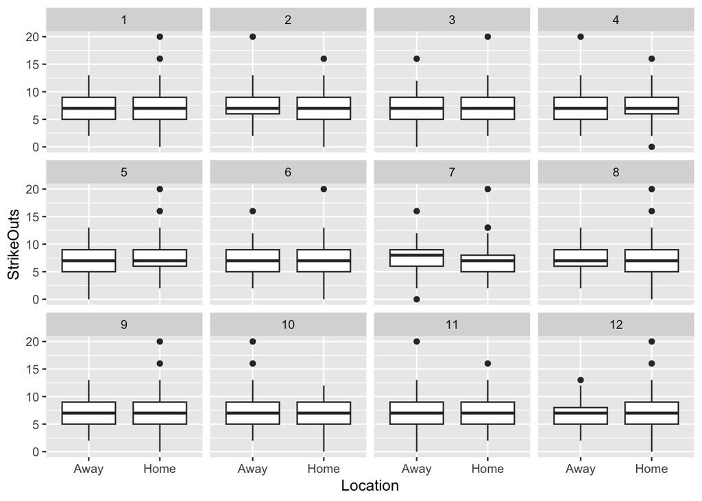

```r
ggplot(perms_Location, aes(x = Location, y = StrikeOuts)) +
  geom_boxplot() +
  facet_wrap(~.sample)
```

```r
#"nsW7 Ykjk l3 gCPljlC3 4b"
decrypt("nsW7 Ykjk l3 gCPljlC3 4b")
```

```
[1] "True data in position  7"
```

2. Calcula el promedio de strikes por juego en cada grupo (donde grupo se define por Location).

   ```r
   resumen_Strikes <- phillies  |>  group_by(Location) |>
     summarise(media_Strikes = mean(StrikeOuts)) |>
     pivot_wider(names_from = Location, values_from = media_Strikes) |>
     mutate(difference = Home - Away)

   glimpse(resumen_Strikes)
   ```

   ```
   Rows: 1
   Columns: 3
   $ Away       <dbl> 7.308642
   $ Home       <dbl> 6.950617
   $ difference <dbl> -0.3580247
   ```

3. Realiza una prueba de permutación para la diferencia de las medias. Grafica la distribución de referencia y calcula el valor *p* de dos colas.

   ```r
   set.seed(123)
   Location_StrikeOut_tbl <- phillies  |>  select(Location, StrikeOuts)
   # cinco mil permutaciones
   perms_StrikeOuts <- lineup(null_permute("StrikeOuts"),
                           Location_StrikeOut_tbl, n = 5000)
   ```

   ```
   decrypt("nsW7 Ykjk l3 gCPljlC3 4bFb")
   ```

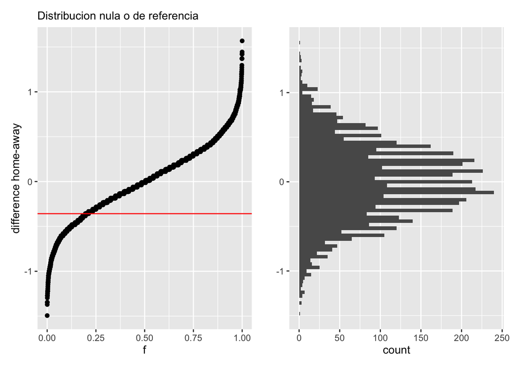

   ```r
   #glimpse(perms_StrikeOuts)

   perm_test <- perms_StrikeOuts |>
     group_by(.sample, Location) |>
     summarise(mean_values_per_sample = mean(StrikeOuts)) |>
     pivot_wider(names_from = Location, values_from = mean_values_per_sample) |>
     mutate(difference_per_sample = Home - Away)
   g1 <- ggplot(perm_test, aes(sample=difference_per_sample)) +
     geom_qq(distribution=stats::qunif) +
     geom_hline(yintercept = resumen_Strikes$difference, color = "red") +
     xlab("f") + ylab("difference home-away") +labs(subtitle = "Distribucion nula o de referencia")

   g2 <- ggplot(perm_test, aes(x=difference_per_sample)) +
     geom_histogram(binwidth = 0.04) +
     coord_flip() +
     xlab("") +  labs(subtitle = "")

   g1 + g2
   ```

   ```r
   dist_ref <- ecdf(resumen_Strikes$difference)
   valor_p <- 2 * min(dist_ref(resumen_Strikes$difference), (1 - dist_ref(resumen_Strikes$difference)))
   valor_p
   ```